# Ruifan - PSTAT131 Lab03

```r
# install.packages("ISLR")
# install.packages("ISLR2")
```

```r
# install.packages("discrim")
# install.packages("poissonreg")
# install.packages("corrr")
# install.packages("klaR")
```

```r
library(tidymodels)
library(ISLR) # For the Smarket data set
library(ISLR2) # For the Bikeshare data set
library(discrim)
library(poissonreg)
library(corrr)
library(klaR) # for naive bayes
tidymodels_prefer()
```

```r
library(readr)
```

```r
titanic <- read_csv("~/Downloads/homework-3/data/titanic.csv")
titanic$survived = factor(titanic$survived, levels = c("Yes", "No"))
titanic$sex = factor(titanic$sex)
titanic$pclass = factor(titanic$pclass)
```

### Question 1

Split the data, stratifying on the outcome variable, survived. You should choose the proportions to split the data into.

```r
set.seed(168)

titanic_split <- initial_split(titanic, prop = 0.70,
                                strata = survived)
titanic_train <- training(titanic_split)
titanic_test <- testing(titanic_split)
```

Verify that the training and testing data sets have the appropriate number of observations. Take a look at the training data and note any potential issues, such as missing data.

```r
summary(titanic_test)
```

```
##   passenger_id   survived  pclass      name               sex
##  Min.   : 15.0   Yes:103   1: 68   Length:268         female: 88
##  1st Qu.:244.0   No :165   2: 55   Class :character   male  :180
##  Median :461.5             3:145   Mode  :character
##  Mean   :454.5
##  3rd Qu.:677.8
##  Max.   :889.0
##
##       age            sib_sp           parch           ticket
##  Min.   : 0.67   Min.   :0.0000   Min.   :0.0000   Length:268
##  1st Qu.:19.00   1st Qu.:0.0000   1st Qu.:0.0000   Class :character
##  Median :27.50   Median :0.0000   Median :0.0000   Mode  :character
##  Mean   :29.04   Mean   :0.5224   Mean   :0.3918
##  3rd Qu.:39.25   3rd Qu.:1.0000   3rd Qu.:1.0000
##  Max.   :80.00   Max.   :8.0000   Max.   :5.0000
##  NA's   :52
##       fare           cabin             embarked
##  Min.   :  0.00   Length:268         Length:268
##  1st Qu.:  8.05   Class :character   Class :character
##  Median : 15.50   Mode  :character   Mode  :character
##  Mean   : 33.13
##  3rd Qu.: 30.70
##  Max.   :512.33
##
```

```r
summary(titanic_train)
```

```
##   passenger_id   survived  pclass      name               sex
##  Min.   :  1.0   Yes:239   1:148   Length:623         female:226
##  1st Qu.:218.5   No :384   2:129   Class :character   male  :397
##  Median :436.0             3:346   Mode  :character
##  Mean   :442.3
##  3rd Qu.:664.5
##  Max.   :891.0
##
##       age            sib_sp           parch           ticket
##  Min.   : 0.42   Min.   :0.0000   Min.   :0.0000   Length:623
##  1st Qu.:21.00   1st Qu.:0.0000   1st Qu.:0.0000   Class :character
##  Median :28.00   Median :0.0000   Median :0.0000   Mode  :character
##  Mean   :29.99   Mean   :0.5233   Mean   :0.3772
##  3rd Qu.:38.00   3rd Qu.:1.0000   3rd Qu.:0.0000
##  Max.   :74.00   Max.   :8.0000   Max.   :6.0000
##  NA's   :125
##       fare            cabin             embarked
##  Min.   :  0.000   Length:623         Length:623
##  1st Qu.:  7.896   Class :character   Class :character
##  Median : 13.863   Mode  :character   Mode  :character
##  Mean   : 31.808
##  3rd Qu.: 31.137
##  Max.   :512.329
##
```

Titanic_test has 268 observations and the titanic-train has 623 observations. By adding them together, there are 891 observations in total, which is 891 observations in the data set. there are many missing data in variable age and cabin.

Why is it a good idea to use stratified sampling for this data?

Stratified random sampling allows us to obtain a sample population that best represents the entire population being studied. It also involves dividing the entire population into homogeneous groups called strata.  
(Source: https://www.investopedia.com/terms/stratified_random_sampling.asp)

### Question 2

Using the training data set, explore/describe the distribution of the outcome variable survived.

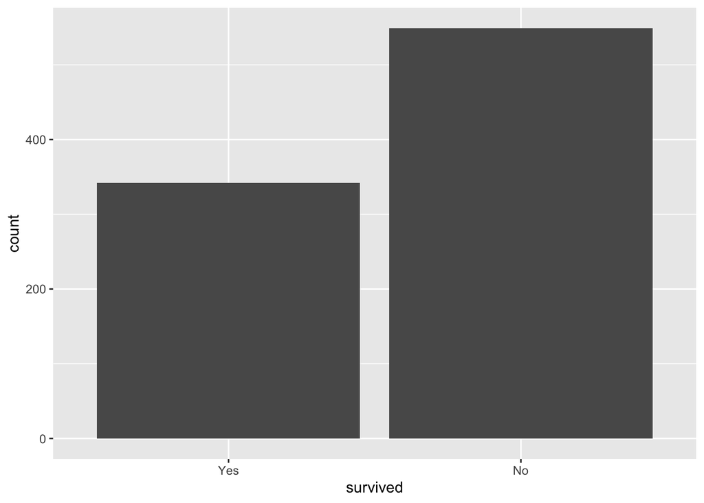

```r
titanic %>%
  ggplot(aes(x = survived)) +
  geom_bar()
```

The distribution of survived variable shows that there are more people not survived that whom survived.

### Question 3

Using the training data set, create a correlation matrix of all continuous variables. Create a visualization of the matrix, and describe any patterns you see. Are any predictors correlated with each other? Which ones, and in which direction?

```r
cor_titanic <- titanic_train %>%
  select(age, sib_sp, parch, fare) %>%
  correlate()
```

```
##
## Correlation method: 'pearson'
## Missing treated using: 'pairwise.complete.obs'
```

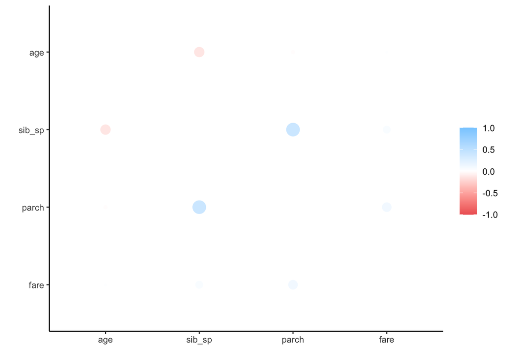

```r
rplot(cor_titanic)
```

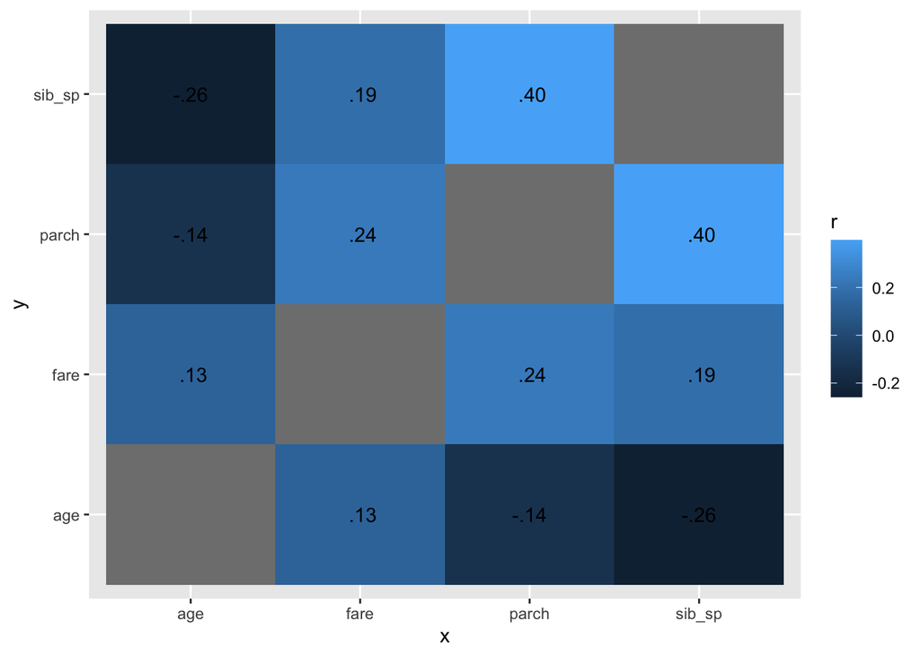

```r
cor_titanic %>%
  stretch() %>%
  ggplot(aes(x, y, fill = r)) +
  geom_tile() +
  geom_text(aes(label = as.character(fashion(r))))
```

### Question 4

Using the training data, create a recipe predicting the outcome variable survived. Include the following predictors: ticket class, sex, age, number of siblings or spouses aboard, number of parents or children aboard, and passenger fare.

Recall that there were missing values for age. To deal with this, add an imputation step using step_impute_linear(). Next, use step_dummy() to dummy encode categorical predictors. Finally, include interactions between:

Sex and passenger fare, and Age and passenger fare. You’ll need to investigate the tidymodels documentation to find the appropriate step functions to use.

```r
titanic_recipe <- recipe(survived ~ age + pclass + fare + sex + sib_sp + parch, data = titanic_train) %>%
  step_dummy(all_nominal_predictors()) %>%
  step_impute_linear(age) %>%
  step_interact(terms = ~age:fare + sex_male:fare, role = "predictor") #%>%
 # prep()
```

```r
summary(titanic_recipe)
```

```
## # A tibble: 7 × 4
##   variable type    role      source
##   <chr>    <chr>   <chr>     <chr>
## 1 age      numeric predictor original
## 2 pclass   nominal predictor original
## 3 fare     numeric predictor original
## 4 sex      nominal predictor original
## 5 sib_sp   numeric predictor original
## 6 parch    numeric predictor original
## 7 survived nominal outcome   original
```

### Question 5

Specify a logistic regression model for classification using the “glm” engine. Then create a workflow. Add your model and the appropriate recipe. Finally, use fit() to apply your workflow to the training data.

```r
log_reg <- logistic_reg() %>%
  set_engine("glm") %>%
  set_mode("classification")
```

```r
log_wkflow <- workflow() %>%
  add_model(log_reg) %>%
  add_recipe(titanic_recipe)

log_fit <- fit(log_wkflow, titanic_train)
tidy(log_fit)
```

```
## # A tibble: 10 × 5
##    term             estimate std.error statistic  p.value
##    <chr>               <dbl>     <dbl>     <dbl>    <dbl>
##  1 (Intercept)     -4.68      0.672       -6.96  3.41e-12
##  2 age              0.0689    0.0137       5.02  5.08e- 7
##  3 fare             0.00835   0.00937      0.891 3.73e- 1
##  4 sib_sp           0.338     0.131        2.57  1.01e- 2
##  5 parch            0.202     0.143        1.41  1.57e- 1
##  6 pclass_X2        1.37      0.377        3.64  2.75e- 4
##  7 pclass_X3        2.33      0.381        6.12  9.30e-10
##  8 sex_male         2.45      0.293        8.38  5.30e-17
##  9 age_x_fare      -0.000547  0.000231    -2.37  1.78e- 2
## 10 fare_x_sex_male  0.00946   0.00714      1.33  1.85e- 1
```

```r
log_reg_acc <- augment(log_fit, new_data = titanic_train) %>%
  accuracy(truth = survived, estimate = .pred_class)
log_reg_acc
```

```
## # A tibble: 1 × 3
##   .metric  .estimator .estimate
##   <chr>    <chr>          <dbl>
## 1 accuracy binary         0.809
```

### Question 6

Repeat Question 5, but this time specify a linear discriminant analysis model for classification using the “MASS” engine.

```r
lda_mod <- discrim_linear() %>%
  set_mode("classification") %>%
  set_engine("MASS")

lda_wkflow <- workflow() %>%
  add_model(lda_mod) %>%
  add_recipe(titanic_recipe)

lda_fit <- fit(lda_wkflow, titanic_train)
```

```r
lda_reg_acc <- augment(lda_fit, new_data = titanic_train) %>%
  accuracy(truth = survived, estimate = .pred_class)
lda_reg_acc
```

```
## # A tibble: 1 × 3
##   .metric  .estimator .estimate
##   <chr>    <chr>          <dbl>
## 1 accuracy binary         0.799
```

### Question 7

Repeat Question 5, but this time specify a quadratic discriminant analysis model for classification using the “MASS” engine.

```r
qda_mod <- discrim_quad() %>%
  set_mode("classification") %>%
  set_engine("MASS")

qda_wkflow <- workflow() %>%
  add_model(qda_mod) %>%
  add_recipe(titanic_recipe)

qda_fit <- fit(qda_wkflow, titanic_train)
```

```r
predict(lda_fit, new_data = titanic_train, type = "prob")
```

```
## # A tibble: 623 × 2
##    .pred_Yes .pred_No
##        <dbl>    <dbl>
##  1   0.0744     0.926
##  2   0.0456     0.954
##  3   0.0669     0.933
##  4   0.228      0.772
##  5   0.0975     0.903
##  6   0.107      0.893
##  7   0.00993    0.990
##  8   0.0699     0.930
##  9   0.125      0.875
## 10   0.0668     0.933
## # … with 613 more rows
```

```r
qda_reg_acc <- augment(qda_fit, new_data = titanic_train) %>%
  accuracy(truth = survived, estimate = .pred_class)
qda_reg_acc
```

```
## # A tibble: 1 × 3
##   .metric  .estimator .estimate
##   <chr>    <chr>          <dbl>
## 1 accuracy binary         0.778
```

### Question 8

Repeat Question 5, but this time specify a naive Bayes model for classification using the “klaR” engine. Set the usekernel argument to FALSE.

```r
nb_mod <- naive_Bayes() %>%
  set_mode("classification") %>%
  set_engine("klaR") %>%
  set_args(usekernel = FALSE)

nb_wkflow <- workflow() %>%
  add_model(nb_mod) %>%
  add_recipe(titanic_recipe)

nb_fit <- fit(nb_wkflow, titanic_train)
```

```r
predict(nb_fit, new_data = titanic_train, type = "prob")
```

```
## # A tibble: 623 × 2
##    .pred_Yes .pred_No
##        <dbl>    <dbl>
##  1 0.0241       0.976
##  2 0.0204       0.980
##  3 0.0219       0.978
##  4 0.268        0.732
##  5 0.000618     0.999
##  6 0.0243       0.976
##  7 0.000518     0.999
##  8 0.0000124    1.00
##  9 0.0968       0.903
## 10 0.0223       0.978
## # … with 613 more rows
```

```r
nb_reg_acc <- augment(nb_fit, new_data = titanic_train) %>%
  accuracy(truth = survived, estimate = .pred_class)
nb_reg_acc
```

```
## # A tibble: 1 × 3
##   .metric  .estimator .estimate
##   <chr>    <chr>          <dbl>
## 1 accuracy binary         0.772
```

### Question 9

Now you’ve fit four different models to your training data.

Use predict() and bind_cols() to generate predictions using each of these 4 models and your training data. Then use the accuracy metric to assess the performance of each of the four models.

Which model achieved the highest accuracy on the training data?

```r
prediction_models = bind_cols(predict(log_fit, titanic_test), predict(lda_fit, titanic_test), predict(qda_fit, titanic_test), predict(nb_fit, titanic_test))
```

```
## * .pred_class -> .pred_class...1
## * .pred_class -> .pred_class...2
## * .pred_class -> .pred_class...3
## * .pred_class -> .pred_class...4
```

```r
colnames(prediction_models) = c("log_prediction", "lda_prediction", "qda_prediction", "nb_prediction")
head(prediction_models)
```

```
## # A tibble: 6 × 4
##   log_prediction lda_prediction qda_prediction nb_prediction
##   <fct>          <fct>          <fct>          <fct>
## 1 Yes            Yes            Yes            No
## 2 No             Yes            No             Yes
## 3 No             No             No             No
## 4 Yes            Yes            No             No
## 5 Yes            Yes            No             No
## 6 Yes            Yes            Yes            Yes
```

```r
accuracies <- c(log_reg_acc$.estimate, lda_reg_acc$.estimate,
                nb_reg_acc$.estimate, qda_reg_acc$.estimate)
models <- c("Logistic Regression", "LDA", "Naive Bayes", "QDA")
results <- tibble(accuracies = accuracies, models = models)
results %>%
  arrange(-accuracies)
```

```
## # A tibble: 4 × 2
##   accuracies models
##        <dbl> <chr>
## 1      0.809 Logistic Regression
## 2      0.799 LDA
## 3      0.778 QDA
## 4      0.772 Naive Bayes
```

We can see that logistic regression perform the best.

### Question 10

Fit the model with the highest training accuracy to the testing data. Report the accuracy of the model on the testing data.

How did the model perform? Compare its training and testing accuracies. If the values differ, why do you think this is so?

```r
predict(log_fit, new_data = titanic_test, type = "prob")
```

```
## # A tibble: 268 × 2
##    .pred_Yes .pred_No
##        <dbl>    <dbl>
##  1    0.798    0.202
##  2    0.466    0.534
##  3    0.187    0.813
##  4    0.506    0.494
##  5    0.621    0.379
##  6    0.970    0.0296
##  7    0.167    0.833
##  8    0.111    0.889
##  9    0.0992   0.901
## 10    0.0867   0.913
## # … with 258 more rows
```

Then, we can see the confusion matrix and accuracy

```r
augment(log_fit, new_data = titanic_test) %>%
  conf_mat(truth = survived, estimate = .pred_class)
```

```
##           Truth
## Prediction Yes  No
##        Yes  67  18
##        No   36 147
```

```r
log_reg_acc <- augment(log_fit, new_data = titanic_test) %>%
  accuracy(truth = survived, estimate = .pred_class)
log_reg_acc
```

```
## # A tibble: 1 × 3
##   .metric  .estimator .estimate
##   <chr>    <chr>          <dbl>
## 1 accuracy binary         0.799
```

after testing the accuracy, we can try to see the sensitivity and specificity as the lab did and see what will happen.

```r
multi_metric <- metric_set(accuracy, sensitivity, specificity)

augment(log_fit, new_data = titanic_test) %>%
  multi_metric(truth = survived, estimate = .pred_class)
```

```
## # A tibble: 3 × 3
##   .metric     .estimator .estimate
##   <chr>       <chr>          <dbl>
## 1 accuracy    binary         0.799
## 2 sensitivity binary         0.650
## 3 specificity binary         0.891
```

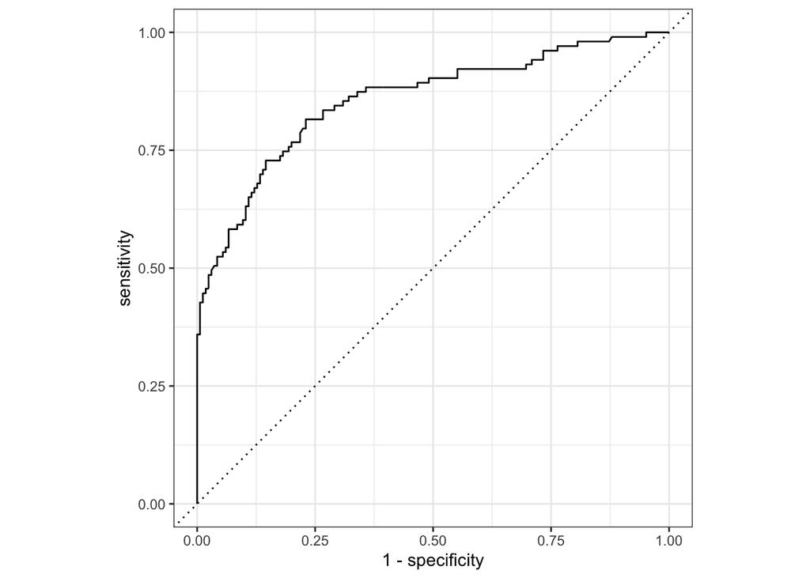

```r
augment(log_fit, new_data = titanic_test) %>%
  roc_curve(survived, .pred_Yes) %>%
  autoplot()
```